# Chapter10 Unsupervised Learning

Tomoya Fukumoto

2019-05-03

## 10.4 Lab 1: Principal Components Analysis

### Preparation

#### Environment

```r
library(dplyr)
library(ggplot2)
```

#### data

```r
USArrests %>% as_tibble(rownames = "states")
```

```
## # A tibble: 50 x 5
##    states      Murder Assault UrbanPop  Rape
##    <chr>        <dbl>   <int>    <int> <dbl>
##  1 Alabama       13.2     236       58  21.2
##  2 Alaska        10       263       48  44.5
##  3 Arizona        8.1     294       80  31
##  4 Arkansas       8.8     190       50  19.5
##  5 California     9       276       91  40.6
##  6 Colorado       7.9     204       78  38.7
##  7 Connecticut    3.3     110       77  11.1
##  8 Delaware       5.9     238       72  15.8
##  9 Florida       15.4     335       80  31.9
## 10 Georgia       17.4     211       60  25.8
## # ... with 40 more rows
```

```r
class(USArrests)
```

```
## [1] "data.frame"
```

### do PCA

```r
pr.out <- prcomp(USArrests, scale = TRUE)
```

主成分分析では説明変数ごとにスケールが一致していなければならない。 `scale = TRUE`とすると自動でスケール合わせをしてくれる。 なお、スケール合わせとは変数ごとに平均値と標準偏差を計算してそれぞれを0, 1に調整する作業のこと。

第一引数にformula式を設定すればPCAする変数を指定することもできる。

```r
prcomp(~ Murder + Assault + UrbanPop, USArrests, scale = TRUE)
```

```
## Standard deviations:
## [1] 1.3656547 0.9795415 0.4189100
##
## Rotation:
##                 PC1         PC2        PC3
## Murder   -0.6672955  0.30345520  0.6801703
## Assault  -0.6970818  0.06713997 -0.7138411
## UrbanPop -0.2622854 -0.95047734  0.1667309
```

### `prcomp`の結果確認

#### loading vectorの取得

全主成分についての結果が行列として帰ってくる(rotation matrix)

```r
pr.out$rotation
```

```
##                 PC1        PC2        PC3         PC4
## Murder   -0.5358995  0.4181809 -0.3412327  0.64922780
## Assault  -0.5831836  0.1879856 -0.2681484 -0.74340748
## UrbanPop -0.2781909 -0.8728062 -0.3780158  0.13387773
## Rape     -0.5434321 -0.1673186  0.8177779  0.08902432
```

```r
#第一主成分のloading vectorだけを取得する
pr.out$rotation[,1]
```

```
##     Murder    Assault   UrbanPop       Rape
## -0.5358995 -0.5831836 -0.2781909 -0.5434321
```

#### scoreの取得

全主成分についての結果が行列として帰ってくる。

```r
pr.out$x %>% as_tibble(rownames = "states")
```

```
## # A tibble: 50 x 5
##    states          PC1     PC2     PC3      PC4
##    <chr>         <dbl>   <dbl>   <dbl>    <dbl>
##  1 Alabama     -0.976   1.12   -0.440   0.155
##  2 Alaska      -1.93    1.06    2.02   -0.434
##  3 Arizona     -1.75   -0.738   0.0542 -0.826
##  4 Arkansas     0.140   1.11    0.113  -0.181
##  5 California  -2.50   -1.53    0.593  -0.339
##  6 Colorado    -1.50   -0.978   1.08    0.00145
##  7 Connecticut  1.34   -1.08   -0.637  -0.117
##  8 Delaware    -0.0472 -0.322  -0.711  -0.873
##  9 Florida     -2.98    0.0388 -0.571  -0.0953
## 10 Georgia     -1.62    1.27   -0.339   1.07
## # ... with 40 more rows
```

```r
#理屈どおりか確認
#元データとloading vectorからscoreを再現できる
#下の計算がpro.out$x[1,1]と一致する
alabama.scaled <- (USArrests[1,] - pr.out$center) / pr.out$scale
sum(alabama.scaled * pr.out$rotation[,1])
```

```
## [1] -0.9756604
```

### 主成分分析の可視化

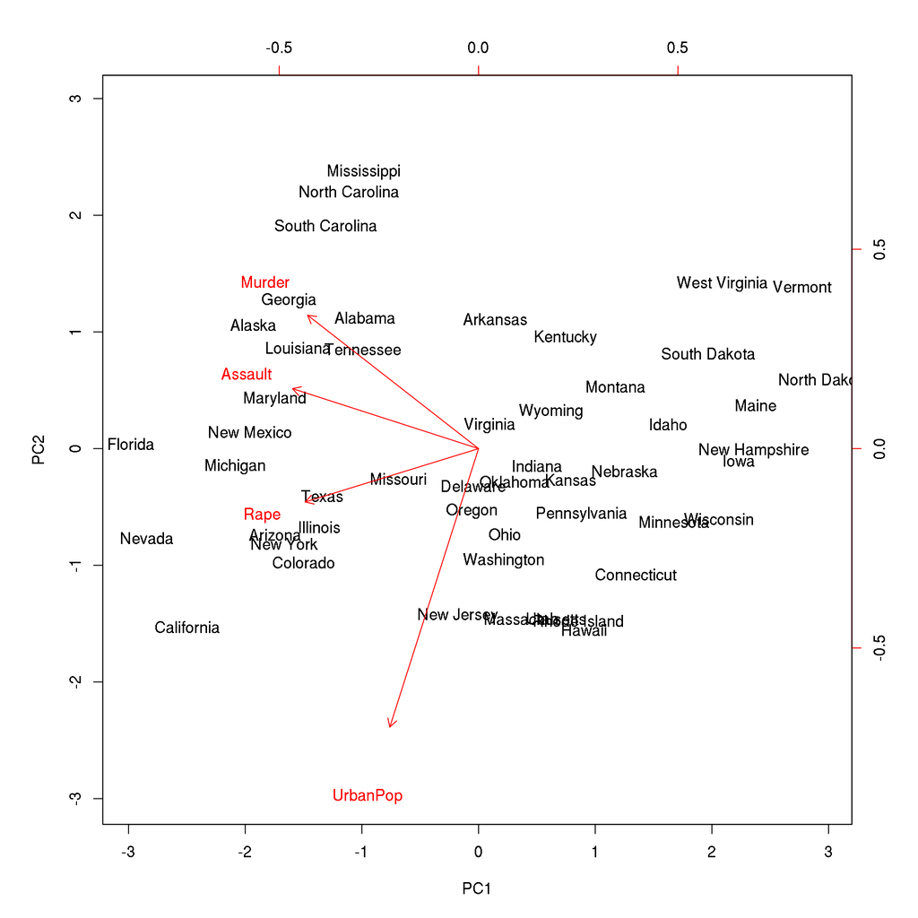

```r
biplot(pr.out, scale = 0)
```

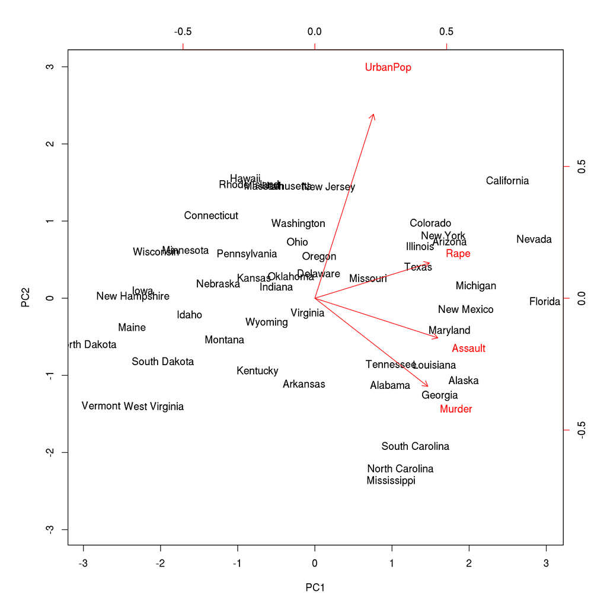

```r
#loading vectorの正負を反転させてもOK
pr.out$rotation <- - pr.out$rotation
pr.out$x <- - pr.out$x
biplot(pr.out, scale = 0)
```

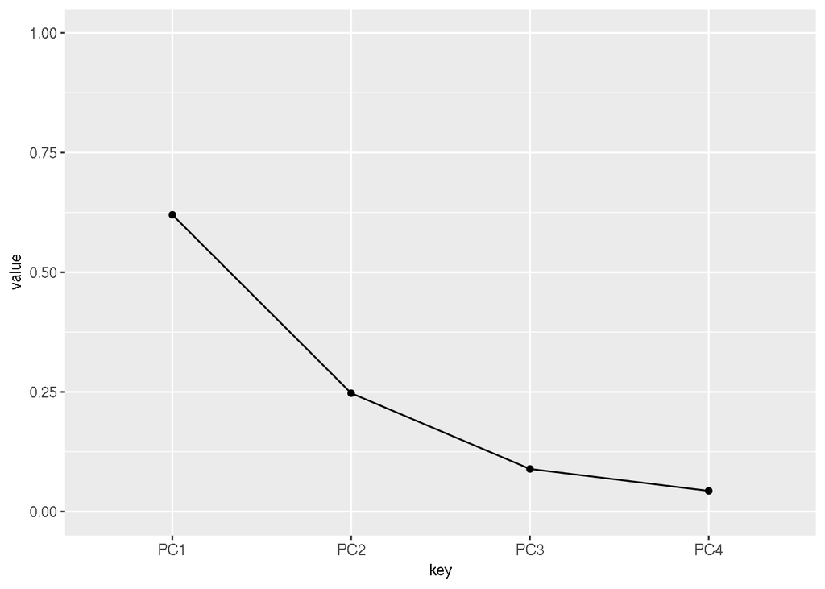

```r
#scree plot
pve <- pr.out$x %>% as_tibble %>%
  summarise_all(var) %>%
  tidyr::gather(key, value) %>%
  mutate(value = value / sum(value))

pve %>%
  ggplot(aes(key, value)) + geom_line(aes(group = 1)) + geom_point() + ylim(0,1)
```

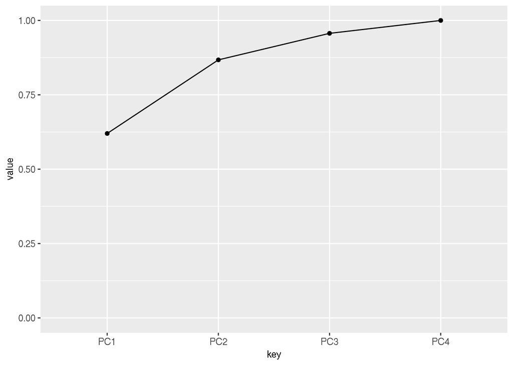

```r
pve %>%
  mutate(value = cumsum(value)) %>%
  ggplot(aes(key, value)) + geom_line(aes(group = 1)) + geom_point() + ylim(0,1)
```

## 10.5 Clustering, K-Means

### Preparation

#### Environment

```r
library(dplyr)
library(ggplot2)
```

#### data

```r
set.seed(2)
x <- matrix(rnorm(50*2), ncol = 2)
#first 25 observations are under different distribution
x[1:25, 1] <- x[1:25, 1] + 3
x[1:25, 2] <- x[1:25, 2] - 4
```

### do K-Means

- main function: `kmeans`
  - メインデータは**行列**
  - 第二引数はクラスタ数（今回は2）
  - `nstart`は必須パラメータ(後述)

```r
km.out <- kmeans(x, 2, nstart = 20)
```

`nstart`は一番始めのクラスタリングのためにランダムサンプルする数。 小さいと局所最適に落ち込んでしまう危険があるので、著者は20か50程度の大きめの数字を推奨している。

### 結果

```r
km.out$cluster
```

```
##  [1] 2 2 2 2 2 2 2 2 2 2 2 2 2 2 2 2 2 2 2 2 2 2 2 2 2 1 1 1 1 1 1 1 1 1 1
## [36] 1 1 1 1 1 1 1 1 1 1 1 1 1 1 1
```

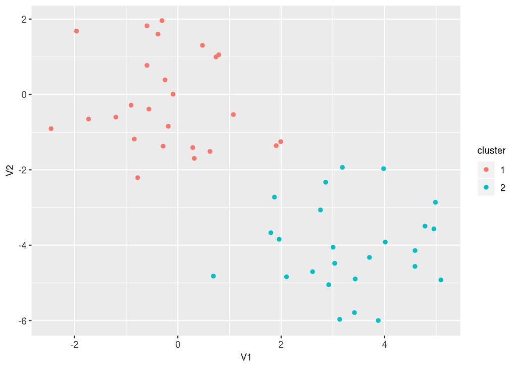

```r
x %>%
  as_tibble %>%
  mutate(cluster = km.out$cluster %>% factor) %>%
  ggplot(aes(V1, V2)) + geom_point(aes(color = cluster))
```

```r
km.out
```

```
## K-means clustering with 2 clusters of sizes 25, 25
##
## Cluster means:
##         [,1]       [,2]
## 1 -0.1956978 -0.1848774
## 2  3.3339737 -4.0761910
##
## Clustering vector:
##  [1] 2 2 2 2 2 2 2 2 2 2 2 2 2 2 2 2 2 2 2 2 2 2 2 2 2 1 1 1 1 1 1 1 1 1 1
## [36] 1 1 1 1 1 1 1 1 1 1 1 1 1 1 1
##
## Within cluster sum of squares by cluster:
## [1] 65.40068 63.20595
##  (between_SS / total_SS =  72.8 %)
##
## Available components:
##
## [1] "cluster"      "centers"      "totss"        "withinss"
## [5] "tot.withinss" "betweenss"    "size"         "iter"
## [9] "ifault"
```

始めの２５個を正しくクラスタリングできているようだ。

## lab 2: Clustering, Hierarchical

### Preparation

#### data

```r
x.dist <- dist(x)
```

- `x`はk-meansで使ったのと同じ
- `dist`は`x`のすべての行の組み合わせについて距離ベクトル(dist型)を返す関数。
  - 後述の`hclust`関数は入力としてdist型を要求するので必須
  - デフォルトでは距離はユークリッド距離だが、オプション`method`を使えば最大値距離($L^\infty$)やマンハッタン距離($L^1$)とかも選択できる

### do Hierarchical Clustering

```r
hc.ward <- hclust(x.dist, method = "ward.D")
hc.complete <- hclust(x.dist, method = "complete")
hc.single <- hclust(x.dist, method = "single")
hc.average <- hclust(x.dist, method = "average")
```

- `method`はクラスター間の距離の定義方法
  - ward.Dはわゆるウォード法による。計算量は多いが総合的によいらしい
  - completeはクラスターの要素ごとの距離の中で最大のもの。計算量少ない
  - singleは最小の要素間距離。あんまり良くない
  - averageは要素間距離の平均値

### visualize hclust

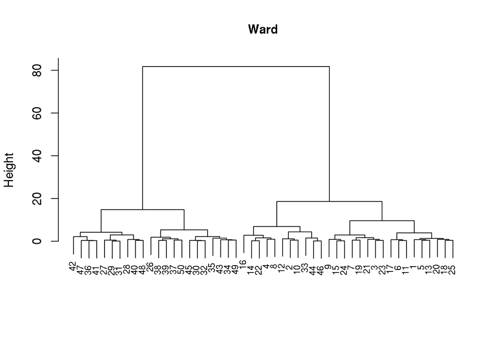

```r
plot(hc.ward, main = "Ward", xlab = "", sub = "", cex = .9)
```

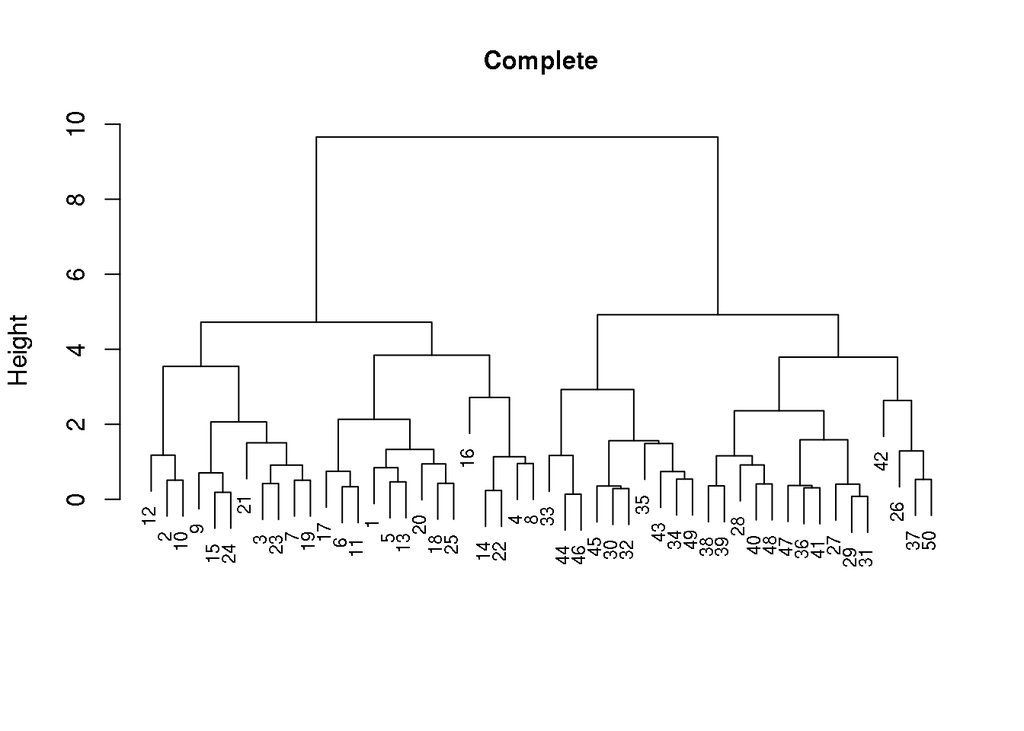

```r
plot(hc.complete, main = "Complete", xlab = "", sub = "", cex = .9)
```

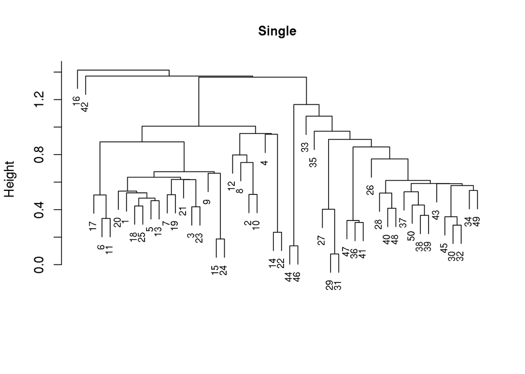

```r
plot(hc.single, main = "Single", xlab = "", sub = "", cex = .9)
```

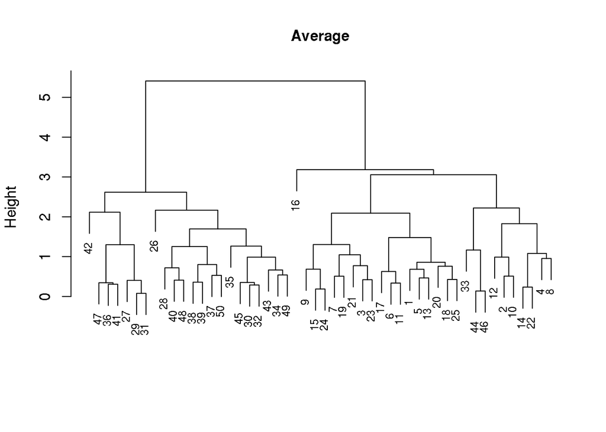

```r
plot(hc.average, main = "Average", xlab = "", sub = "", cex = .9)
```

見た目からしてSingleはよくない。 CompleteよりもWardの方が明確に分類できている。

### Analysis

#### `cutree`

関数`cutree`で各要素がどのクラスタに分類されたのかというベクトルが得られる。 `k`か`h`のどちらかを指定し、`k`ではクラスタ数、`h`ではHeightでの分類結果を得る。

```r
cutree(hc.ward, k = 2)
```

```
##  [1] 1 1 1 1 1 1 1 1 1 1 1 1 1 1 1 1 1 1 1 1 1 1 1 1 1 2 2 2 2 2 2 2 1 2 2
## [36] 2 2 2 2 2 2 2 2 1 2 1 2 2 2 2
```

```r
cutree(hc.ward, h = 20)
```

```
##  [1] 1 1 1 1 1 1 1 1 1 1 1 1 1 1 1 1 1 1 1 1 1 1 1 1 1 2 2 2 2 2 2 2 1 2 2
## [36] 2 2 2 2 2 2 2 2 1 2 1 2 2 2 2
```

これを使ってクラスタリング結果の精度を検証する。

```r
colSums(matrix(cutree(hc.ward, k = 2) , ncol = 2) == c(rep(1,25), rep(2,25)))
```

```
## [1] 25 22
```

```r
colSums(matrix(cutree(hc.complete, k = 2) , ncol = 2) == c(rep(1,25), rep(2,25)))
```

```
## [1] 25 25
```

```r
colSums(matrix(cutree(hc.single, k = 2) , ncol = 2) == c(rep(1,25), rep(2,25)))
```

```
## [1] 24  0
```

```r
colSums(matrix(cutree(hc.average, k = 2) , ncol = 2) == c(rep(1,25), rep(2,25)))
```

```
## [1] 25 22
```

Completeは100点満点なのに対してward, averageは一部間違っている。 singleはポンコツ

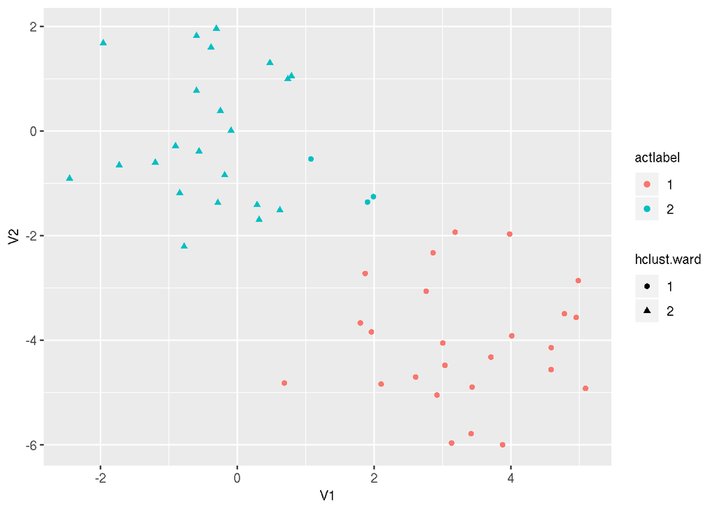

```r
as_tibble(x) %>%
  mutate(
    actlabel = c(rep(1,25), rep(2,25)) %>% factor,
    hclust.ward = cutree(hc.ward, k = 2) %>% factor
  ) %>%
  ggplot(aes(V1, V2)) +
    geom_point(aes(color = actlabel, shape = hclust.ward))
```

#### スケール合わせ

要素間の距離をユークリッド距離で定義していると、変数ごとの絶対値の大きさがクラスタリングの結果に影響する。 この影響が好ましくない場合はスケール合わせをする必要がある。

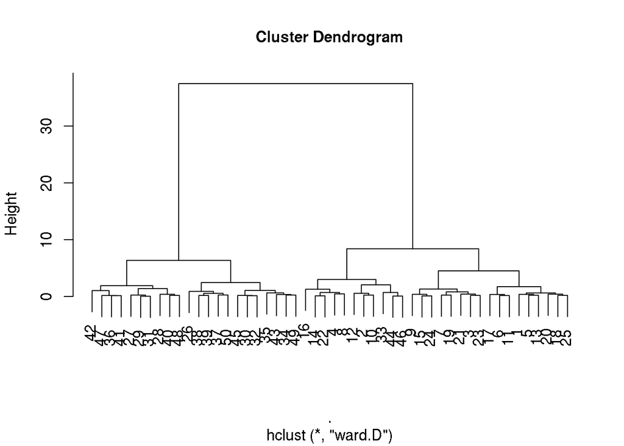

```r
hc.ward.scaled <- x %>% scale %>% dist %>% hclust(method = "ward.D")
plot(hc.ward.scaled)
```

```r
colSums(matrix(cutree(hc.ward.scaled, k = 2) , ncol = 2) == c(rep(1,25), rep(2,25)))
```

```
## [1] 25 22
```

ウォード法についてはあまり変化なし

#### 距離の定義変更(correlation-based distance)

距離をノルムではなく相関で定義することもできる。 ノルムを使うと絶対値の近さが距離を表すが、相関を使うと変数間の傾向が近さを表すので絶対値の差に影響を受けにくくなる。

変数は３つ以上でなければ相関が計算できない。

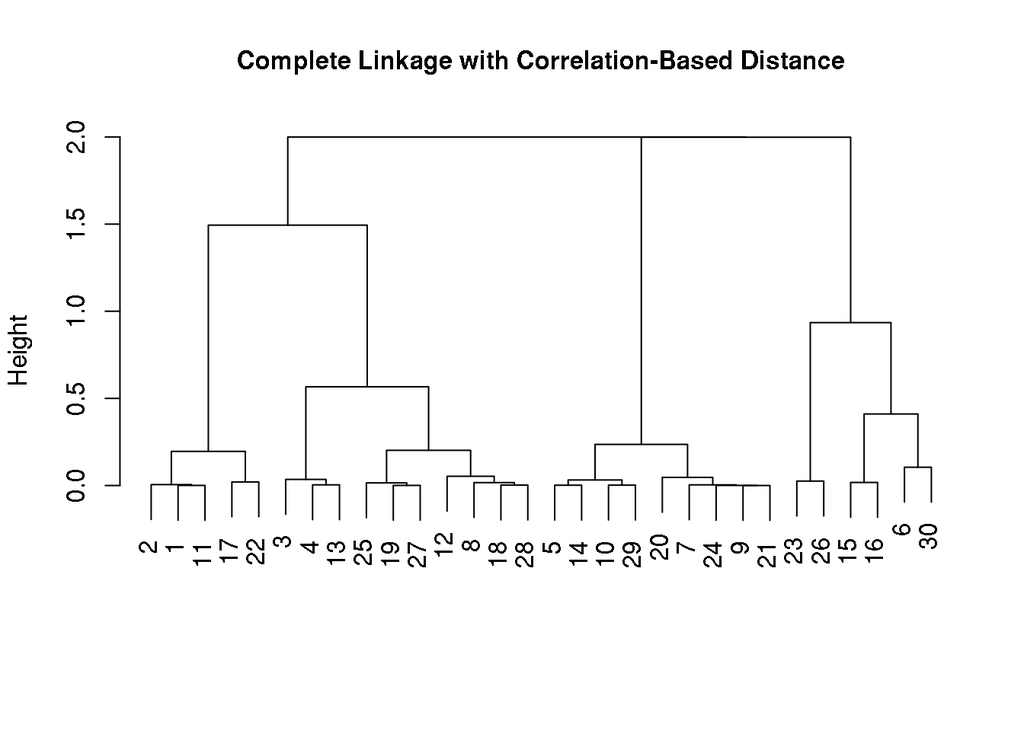

```r
x <- matrix(rnorm(30*3), ncol = 3)
dd <- as.dist(1 - cor(t(x)))
plot(hclust(dd, method = "complete"), main = "Complete Linkage with Correlation-Based Distance", xlab = "", sub = "")
```